# tempoSig: Mutational signature inference using maximum likelihood and NMF

# 1 Introduction

## 1.1 Mutational signatures

The package `tempoSig` implements mutational signature inference functions and utilities primarily based on maximum likelihood algorithms. Input data are mutational catalogs in the form of matrices, which catalog counts of mutation types found in multiple samples into pre-defined classes. The most often-used example is the catalog of single nucleotide substitutions (SBSs) grouped into trinucleotide contexts in which they occur. Mutational signatures are the patterns of the combination of these genetic features recurrent in tumor samples (Nik-Zainal et al. 2012; Alexandrov et al. 2013, 2020). Up to 30 or ~60 recurrent signatures have been established from studies of whole genome and exome sequences of tumor samples (Alexandrov et al. 2020). The discovery of these signatures is based on mathematical decompositions of mutational *catalog*, represented by a matrix $\sf{X}$, of a large sample set into two matrices,
$$\sf{X} \sim \sf{W}\sf{H},$$
where $\sf{W}$ and $\sf{H}$ are *signature* and *exposure* matrices, each containing repertoires of signatures associated with mutational processes operative in samples and the actual numbers of mutations contributed by each signature to individual sample genomes, respectively. The symbol $\sim$ indicates that the actual data are to be regarded as (Poisson) realizations of the mean given by the product on the right.

Two classes of analysis tasks encountered in genetic studies are *de novo* discovery of signatures and *refitting*: in *de novo* discovery, both *signature* and *exposure* matrices are unknown, and large samples of tumor genomes or exomes are used as input (catalog matrix $\sf{X}$ as a whole) for discovery of signatures. The primary algorithm used in *de novo* discovery of signatures is non-negative matrix factorization (Alexandrov et al. 2013). In *refitting*, in contrast, existing signature lists are used (signature matrix $\sf{W}$ given as input) along with input catalogs to estimate the exposure matrix $\sf{H}$, whose columns give relative proportions of signatures present in each sample (Rosenthal et al. 2016).

## 1.2 Maximum likelihood

The refitting functions in `tempoSig` are based on the maximum likelihood inference algorithm adapted from mutation-signatures. In refitting, each column of catalog $\sf{X}$ and exposure $\sf{H}$ matrices, corresponding to each sample to be analyzed, can be treated independent since $\sf{W}$ is assumed known. For a given sample genome, the mutational catalog data consist of the observed counts $m_i$ (a single column of matrix $\sf{X}$), where $i=1,\cdots, c$ is the index denoting the mutation type categories under consideration ($c=96$ for SBS data classified into trinucleotide contexts). The inference task then reduces to the problem of estimating multinomial probabilities $p_i$ of observing each category $i$ out of 96 based on actual count data $m_i$. The log likelihood, or the probability of observing data given parameters $\{p_i\}$, is
$$L = \frac{1}{M}\sum_{i=1}^c m_i \ln p_i = \sum_{i<c}{\hat m}_i \ln p_i +
{\hat m}_c \ln \left(1-\sum_{i<c} p_i\right)$$
where $M=\sum_i m_i$, $L$ is the log likelihood per mutation, ${\hat m}_i=m_i/M$ is the proportion of type $i$ in data, and in the second expression, the constraint $\sum_i p_i=1$ was used to eliminate $p_c$, making independent variable subset $\{p_i,\: (i=1,\cdots,c-1)\}$, explicit.

## 1.3 Significance test

For real mutational data with limited sizes (mutational load $M \sim 100$ or less), it is important to gauge the statistical significance of exposure outcomes ($h_k$ for $k=1,\cdots,K$). In `tempoSig`, $p$-values for each exposure can be estimated with one of three algorithms:

1. Permutation test of signatures (`permutation`)
2. Likelihood ratio test (`lrt`)
3. Permutation sampling of count data (`x.permutation`)

With signature permutation (default), the 96 elements of the reference signature vector $W_{ik}$ for signature $k$ is randomly permuted $N_p$ times. Inference is repeated for each replicate to get exposure samples under the null hypothesis, $\{h_{k}^{(j)}\}$, where $j=1,\cdots, N_p$ is the index for permutation replicates. The $p$-value estimate for the $k$-th signature exposure is
$$P_{k} = \frac{1}{N_p} \sum_j I\left(h_{k}^{(j)} \ge h_{k}\right),$$
where $I(x)$ is the indicator function; i.e., the proportion of replicates for which the observed exposure did not exceed the null values. Note that the resulting p-values are limited in range, with apparent $P_k=0$ indicating that $P_k < 1/N_p$.

In likelihood ratio test, the deviance
$$D_k = 2M\left[ L - L(x_k=0)\right],$$
where $L(x_k=0)$ is the likelihood of the restricted model of signature $k$ exposure zero, is computed. This deviance is distributed by $\chi^2$ with ${\rm d.f.}=1$ in the asymptotic limit $M\rightarrow\infty$ (DeGroot and Schervish 2012). Empirical tests suggest this asymptotic limit is satisfied if $M\sim 10^3$ or larger and the p-value computed will generally be an over-estimate. Therefore, we advise caution in using the likelihood ratio test for smaller mutation load. However, this test can give a quick upper bound estimate of p-values, especially for cases where $P < 10^{-4}$ and permutation test only gives `zero` p-values.

Finally, in count permutation, the catalog data $m_i$ for $i=1,\cdots,c$ are randomly permuted while keeping signatures fixed. This scheme is applied once to all signatures and requires less computation than signature permutation. We found it to genereally yield results similar to signature permutation but does not adequately deal with ``unspecific’’ signatures such as Signature 3 (homologous recombination defect).

# 2 Software usage

## 2.1 Installation

The main non-R dependency for `tempoSig` is [GSL](https://www.gnu.org/software/gsl). It can be installed in Ubuntu Linux by

```bash
$ sudo apt-get install libgsl-dev
```

or in CentOS,

```bash
$ yum install gsl-devel
```

To install `tempoSig` along with its dependencies,

```r
devtools::install_github('mskcc/tempoSig')
```

## 2.2 Data structure

Load the package via

```r
library(tempoSig)
```

The main data structure used by `tempoSig` is of S4 class `tempoSig` with slots:

```r
slotNames('tempoSig')
```

```
#> [1] "catalog" "signat"  "tmb"     "expos"   "pvalue"  "logLik"  "misc"
```

Except `tmb` and `logLik`, which are vectors, all are matrices. We denote by $n$ the number of samples (genomes to be analyzed; total number of columns in matrix $\sf{X}$). The slots are

- `catalog`: catalog data matrix of dimension $c\times n$ with mutation types in rows and samples in columns.
- `signat`: matrix of reference signatures; dimension $c\times K$ with mutation types in rows and signatures in columns.
- `tmb`: vector of length $n$; total mutation burden (sum of all mutations) in each sample.
- `expos`: matrix of inferred exposure values; dimension $n \times K$ with samples in rows and signatures in columns.
- `pvalue`: matrix of estimated $p$-values: dimension $n \times K$ with samples in rows and signatures in columns.
- `logLik`: vector of log-likelihood values for each sample.
- `misc`: List of objects associated with de novo infererence.

The primary input data takes the form of catalog matrix $\sf{X}$. An example is provided by the file

```r
catalog <- system.file('extdata', 'tcga-brca_catalog.txt', package = 'tempoSig')
x <- read.table(catalog)
dim(x)
```

```
#> [1] 96 10
```

```r
x[1:5, 1:2]
```

```
#>         TCGA.BH.A0EI.01A.11D.A10Y.09 TCGA.E9.A22B.01A.11D.A159.09
#> A[C>A]A                            1                            0
#> A[C>A]C                            0                            0
#> A[C>A]G                            0                            0
#> A[C>A]T                            0                            0
#> C[C>A]A                            0                            0
```

```r
rownames(x)
```

```
#>  [1] "A[C>A]A" "A[C>A]C" "A[C>A]G" "A[C>A]T" "C[C>A]A" "C[C>A]C" "C[C>A]G"
#>  [8] "C[C>A]T" "G[C>A]A" "G[C>A]C" "G[C>A]G" "G[C>A]T" "T[C>A]A" "T[C>A]C"
#> [15] "T[C>A]G" "T[C>A]T" "A[C>G]A" "A[C>G]C" "A[C>G]G" "A[C>G]T" "C[C>G]A"
#> [22] "C[C>G]C" "C[C>G]G" "C[C>G]T" "G[C>G]A" "G[C>G]C" "G[C>G]G" "G[C>G]T"
#> [29] "T[C>G]A" "T[C>G]C" "T[C>G]G" "T[C>G]T" "A[C>T]A" "A[C>T]C" "A[C>T]G"
#> [36] "A[C>T]T" "C[C>T]A" "C[C>T]C" "C[C>T]G" "C[C>T]T" "G[C>T]A" "G[C>T]C"
#> [43] "G[C>T]G" "G[C>T]T" "T[C>T]A" "T[C>T]C" "T[C>T]G" "T[C>T]T" "A[T>A]A"
#> [50] "A[T>A]C" "A[T>A]G" "A[T>A]T" "C[T>A]A" "C[T>A]C" "C[T>A]G" "C[T>A]T"
#> [57] "G[T>A]A" "G[T>A]C" "G[T>A]G" "G[T>A]T" "T[T>A]A" "T[T>A]C" "T[T>A]G"
#> [64] "T[T>A]T" "A[T>C]A" "A[T>C]C" "A[T>C]G" "A[T>C]T" "C[T>C]A" "C[T>C]C"
#> [71] "C[T>C]G" "C[T>C]T" "G[T>C]A" "G[T>C]C" "G[T>C]G" "G[T>C]T" "T[T>C]A"
#> [78] "T[T>C]C" "T[T>C]G" "T[T>C]T" "A[T>G]A" "A[T>G]C" "A[T>G]G" "A[T>G]T"
#> [85] "C[T>G]A" "C[T>G]C" "C[T>G]G" "C[T>G]T" "G[T>G]A" "G[T>G]C" "G[T>G]G"
#> [92] "G[T>G]T" "T[T>G]A" "T[T>G]C" "T[T>G]G" "T[T>G]T"
```

This file was generated by taking mutation count data of 10 tumor samples from the mutation annotation format ([MAF](https://docs.gdc.cancer.gov/Data/File_Formats/MAF_Format/)) file of [TCGA BRCA](https://portal.gdc.cancer.gov/projects/TCGA-BRCA) project. The rownames show 96 trinucleotide mutation types with the `ref > alt` inside brackets (`ref` either `C` or `T`; otherwise its complementary base taken) and its two adjacent nucleotides.

An object of class `tempoSig` is created with the catalog data frame as the main argument:

```r
s <- tempoSig(data = x)
s
```

```
#> Class: tempoSig
#> Number of mutation types =  96
#>   [1] "A[C>A]A" "A[C>A]C" "A[C>A]G" "A[C>A]T" "C[C>A]A" "C[C>A]C"
#> Number of samples =  10
#> Number of signatures =  30
#>   [1] "Signature.1" "Signature.2" "Signature.3" "Signature.4" "Signature.5"
#> [6] "Signature.6"
```

The object initiation also can include specification of reference signatures via the optional second argument in `tempoSig(data, signat = NULL)`, which by default is read from the file

```r
sbs <- read.table(system.file('extdata', 'cosmic_snv_signatures_v2.txt',
                              package = 'tempoSig'))
dim(sbs)
```

```
#> [1] 96 30
```

```r
sbs[1:5, 1:5]
```

```
#>         Signature.1  Signature.2 Signature.3 Signature.4 Signature.5
#> A[C>A]A 0.011098326 6.827082e-04  0.02217231      0.0365 0.014941548
#> A[C>A]C 0.009149341 6.191072e-04  0.01787168      0.0309 0.008960918
#> A[C>A]G 0.001490070 9.927896e-05  0.00213834      0.0183 0.002207846
#> A[C>A]T 0.006233885 3.238914e-04  0.01626515      0.0243 0.009206905
#> C[C>A]A 0.006595870 6.774450e-04  0.01878173      0.0461 0.009674904
```

```r
colnames(sbs)
```

```
#>  [1] "Signature.1"  "Signature.2"  "Signature.3"  "Signature.4"  "Signature.5"
#>  [6] "Signature.6"  "Signature.7"  "Signature.8"  "Signature.9"  "Signature.10"
#> [11] "Signature.11" "Signature.12" "Signature.13" "Signature.14" "Signature.15"
#> [16] "Signature.16" "Signature.17" "Signature.18" "Signature.19" "Signature.20"
#> [21] "Signature.21" "Signature.22" "Signature.23" "Signature.24" "Signature.25"
#> [26] "Signature.26" "Signature.27" "Signature.28" "Signature.29" "Signature.30"
```

This reference signature list is that of [COSMIC version 2](https://cancer.sanger.ac.uk/cosmic/signatures_v2.tt). There are other files for alternative references also included:

- `cosmic_sigProfiler_SBS_signatures.txt`: COSMIC version 3 from whole-genome data (sigProfiler)
- `cosmic_sigProfiler_SBS_exome_signatures.txt`: COSMIC version 3 from exome data
- `cosmic_SigAnalyzer_SBS_signatures.txt`: COSMIC version 3 from whole-genome data (SigAnalyzer)
- `cosmic_sigProfiler_SBS_signatures_v3.1.txt`: COSMIC version 3.1

They can be used as follows:

```r
sig2 <- read.table(system.file('extdata', 'cosmic_SigAnalyzer_SBS_signatures.txt',
                               package = 'tempoSig'))
dim(sig2)
```

```
#> [1] 96 60
```

```r
sig2[1:5, 1:5]
```

```
#>                SBS1        SBS2        SBS3       SBS4       SBS5
#> A[C>A]A 0.009903594 0.001409996 0.012781832 0.04939012 0.04717703
#> A[C>A]C 0.008303073 0.001360906 0.041688693 0.03328640 0.01072751
#> A[C>A]G 0.001658722 0.000152330 0.000679370 0.01291876 0.01063804
#> A[C>A]T 0.004127913 0.000788988 0.019214188 0.03560007 0.02198948
#> C[C>A]A 0.004363978 0.000553441 0.007714658 0.08122902 0.02365174
```

```r
s2 <- tempoSig(data = x, signat = sig2)
s2
```

```
#> Class: tempoSig
#> Number of mutation types =  96
#>   [1] "A[C>A]A" "A[C>A]C" "A[C>A]G" "A[C>A]T" "C[C>A]A" "C[C>A]C"
#> Number of samples =  10
#> Number of signatures =  60
#>   [1] "SBS1" "SBS2" "SBS3" "SBS4" "SBS5" "SBS6"
```

The `signat` argument can take the file name directly. For convenience, a character short-hand can also be used:

```r
s_v2 <- tempoSig(data = x, signat = 'v2')  # COSMIC v2 (default)
s_v3 <- tempoSig(data = x, signat = 'SA')  # COSMIC v3 SigAnalyzer
s_v4 <- tempoSig(data = x, signat = 'SP')  # COSMIC v3 sigProfiler
s_v3
```

```
#> Class: tempoSig
#> Number of mutation types =  96
#>   [1] "A[C>A]A" "A[C>A]C" "A[C>A]G" "A[C>A]T" "C[C>A]A" "C[C>A]C"
#> Number of samples =  10
#> Number of signatures =  60
#>   [1] "SBS1" "SBS2" "SBS3" "SBS4" "SBS5" "SBS6"
```

We found that `v2` generally achieves higher power than others under limited mutation loads.

The slots of a `tempoSig` object can be accessed via accessor functions:

```r
tmb(s)
```

```
#> TCGA.BH.A0EI.01A.11D.A10Y.09 TCGA.E9.A22B.01A.11D.A159.09
#>                           18                           50
#> TCGA.OL.A5RV.01A.12D.A28B.09 TCGA.C8.A275.01A.21D.A16D.09
#>                           10                          110
#> TCGA.E2.A1IO.01A.11D.A142.09 TCGA.E9.A22G.01A.11D.A159.09
#>                           10                          103
#> TCGA.D8.A1XY.01A.11D.A14K.09 TCGA.AR.A0TS.01A.11D.A10Y.09
#>                           35                           21
#> TCGA.AC.A3YJ.01A.11D.A22X.09 TCGA.AN.A0AJ.01A.11W.A019.09
#>                           32                           75
```

```r
catalog(s)[1:2,1:2]
```

```
#>         TCGA.BH.A0EI.01A.11D.A10Y.09 TCGA.E9.A22B.01A.11D.A159.09
#> A[C>A]A                            1                            0
#> A[C>A]C                            0                            0
```

```r
expos(s)
```

```
#> <0 x 0 matrix>
```

```r
pvalue(s)
```

```
#> <0 x 0 matrix>
```

Note that slots `expos` and `pvalue` are empty since inference has not been performed yet.

## 2.3 Catalog matrix generation

A common outcome of sequencing experiments takes the form of [MAF](https://docs.gdc.cancer.gov/Data/File_Formats/MAF_Format/) files, which collect variant data of multiple samples with annotations. The package [maftools](https://bioconductor.org/packages/maftools/) can be used to derive catalog matrices from MAF files:

```r
if(!require('BiocManager')) install.packages('BiocManager')
if(!require('maftools')) BiocManager::install('maftools')
if(!require('BSgenome.Hsapiens.UCSC.hg19'))
  BiocManager::install('BSgenome.Hsapiens.UCSC.hg19')
laml.maf <- system.file('extdata', 'tcga_laml.maf.gz', package = 'maftools')
laml <- read.maf(maf = laml.maf)
laml.tnm <- maftools::trinucleotideMatrix(maf = laml, prefix = 'chr', add = TRUE,
                                          ref_genome = 'BSgenome.Hsapiens.UCSC.hg19')
catalog <- t(laml.tnm$nmf_matrix)
```

## 2.4 Refitting

Refitting using maximum likelihood inference is performed by

```r
s <- extractSig(s, progress.bar = TRUE)
```

The option `progress.bar = TRUE` displays a progress bar, useful for large samples. The inference fills the `expos` slot of the object:

```r
expos(s)[1:5,1:2]
```

```
#>                              Signature.1  Signature.2
#> TCGA.BH.A0EI.01A.11D.A10Y.09   0.6086729 6.573189e-02
#> TCGA.E9.A22B.01A.11D.A159.09   0.5075789 2.174481e-01
#> TCGA.OL.A5RV.01A.12D.A28B.09   0.4091344 1.015465e-10
#> TCGA.C8.A275.01A.21D.A16D.09   0.1926831 1.512405e-01
#> TCGA.E2.A1IO.01A.11D.A142.09   0.4620623 1.051635e-01
```

```r
rowSums(expos(s))
```

```
#> TCGA.BH.A0EI.01A.11D.A10Y.09 TCGA.E9.A22B.01A.11D.A159.09
#>                            1                            1
#> TCGA.OL.A5RV.01A.12D.A28B.09 TCGA.C8.A275.01A.21D.A16D.09
#>                            1                            1
#> TCGA.E2.A1IO.01A.11D.A142.09 TCGA.E9.A22G.01A.11D.A159.09
#>                            1                            1
#> TCGA.D8.A1XY.01A.11D.A14K.09 TCGA.AR.A0TS.01A.11D.A10Y.09
#>                            1                            1
#> TCGA.AC.A3YJ.01A.11D.A22X.09 TCGA.AN.A0AJ.01A.11W.A019.09
#>                            1                            1
```

Note that each row gives proportions of reference signatures, which add up to 1.

By default, $p$-value estimation is skipped:

```r
pvalue(s)
```

```
#> <0 x 0 matrix>
```

The flag `compute.pval = TRUE` turns it on:

```r
set.seed(135)
s <- extractSig(s, compute.pval = TRUE, pvtest = 'permutation', nperm = 1000,
                progress.bar = TRUE)
```

```r
pvalue(s)[1:5, 1:5]
```

```
#>                              Signature.1 Signature.2 Signature.3 Signature.4
#> TCGA.BH.A0EI.01A.11D.A10Y.09       0.000       0.069       0.829       0.660
#> TCGA.E9.A22B.01A.11D.A159.09       0.000       0.000       0.585       0.718
#> TCGA.OL.A5RV.01A.12D.A28B.09       0.035       0.897       0.612       0.859
#> TCGA.C8.A275.01A.21D.A16D.09       0.000       0.000       0.406       0.235
#> TCGA.E2.A1IO.01A.11D.A142.09       0.000       0.050       0.488       0.843
#>                              Signature.5
#> TCGA.BH.A0EI.01A.11D.A10Y.09       0.763
#> TCGA.E9.A22B.01A.11D.A159.09       0.362
#> TCGA.OL.A5RV.01A.12D.A28B.09       0.913
#> TCGA.C8.A275.01A.21D.A16D.09       0.411
#> TCGA.E2.A1IO.01A.11D.A142.09       0.627
```

The above uses the default signature permutation algorithm. Note that with the number of permutations `nperm = 1000` (default), the lowest non-zero pvalue is $1/1000$. Therefore, the value of 0 indicates $P < 1/1000$. The other two options for algorithm are `pvtest = 'lrt'` (likelihood ratio test) and `pvtest = 'x.permutation'` (count permutation; see above). We try the `lrt` for comparison:

```r
sl <- extractSig(s, compute.pval = TRUE, pvtest = 'lrt', progress.bar = TRUE)
```

```r
pvalue(sl)[1:5,1:5]
```

```
#>                               Signature.1 Signature.2 Signature.3 Signature.4
#> TCGA.BH.A0EI.01A.11D.A10Y.09 0.0227632061  0.53224536   0.9993035   1.0000000
#> TCGA.E9.A22B.01A.11D.A159.09 0.0005228948  0.00442962   0.9992359   0.9995535
#> TCGA.OL.A5RV.01A.12D.A28B.09 0.1430046260  1.00000000   0.4173138   1.0000000
#> TCGA.C8.A275.01A.21D.A16D.09 0.0490074835  0.03312135   1.0000000   0.7004399
#> TCGA.E2.A1IO.01A.11D.A142.09 0.1011885228  0.36993429   1.0000000   0.9999791
#>                              Signature.5
#> TCGA.BH.A0EI.01A.11D.A10Y.09   1.0000000
#> TCGA.E9.A22B.01A.11D.A159.09   0.9996953
#> TCGA.OL.A5RV.01A.12D.A28B.09   0.9999562
#> TCGA.C8.A275.01A.21D.A16D.09   1.0000000
#> TCGA.E2.A1IO.01A.11D.A142.09   1.0000000
```

Note how $P=0$ in `permutation` comes out as nonzero from `lrt` but generally the values from the latter are larger in magnitude (over-estimation arising from the use of asymptotic $\chi^2$ distrubtion).

## 2.5 Visualization and output

A number of utility functions for plotting and output are included. The function `plotExposure` shows a bar plot of exposure proportions of a specified sample:

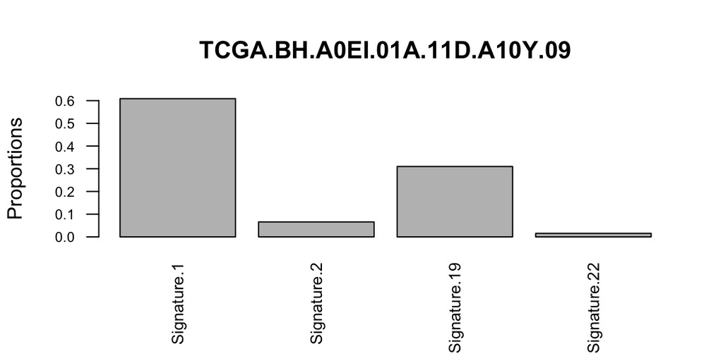

```r
sid <- 'TCGA.BH.A0EI.01A.11D.A10Y.09'
plotExposure(s, sample.id = sid, cutoff = 1e-3, cex.axis = 0.7, cex.names = 0.8)
```

The argument `sample.id` can also be an integer index. The `cutoff` argument filters proportions with the minimum value supplied. The $p$-values

```r
p <- pvalue(s)[sid,]
p[c('Signature.1','Signature.2','Signature.19','Signature.22')]
```

```
#>  Signature.1  Signature.2 Signature.19 Signature.22
#>        0.000        0.069        0.006        0.166
```

indicate `Signature.22` is insignificant and ‘Signature.2’ is borderline. We can get a non-zero upper bound for the `Signature.1` p-value using `lrt`:

```r
p2 <- pvalue(sl)[sid,]
p2[c('Signature.1','Signature.2','Signature.19','Signature.22')]
```

```
#>  Signature.1  Signature.2 Signature.19 Signature.22
#>   0.02276321   0.53224536   0.56031014   0.79093944
```

Again, note the over-estimation under `lrt`.

The function

```r
writeExposure(s, output = 'exposure.tsv', sep = '\t', rm.na = TRUE)
```

will write the exposure, along with $p$-values if any, to a single file. Alternatively, one can choose to write two files, one for exposure and the other for $p$-values via

```r
writeExposure(s, output = 'exposure.tsv', pv.out = 'pvalues.tsv')
```

## 2.6 De novo inference

We illustrate de novo inferences using a larger TCGA-BRCA catalog data:

```r
brca <- read.table(system.file('extdata', 'tcga_brca_mutect_catalog.txt',
                               package = 'tempoSig'))
tcga <- tempoSig(data = brca)
tcga
```

```
#> Class: tempoSig
#> Number of mutation types =  96
#>   [1] "A[C>A]A" "A[C>A]C" "A[C>A]G" "A[C>A]T" "C[C>A]A" "C[C>A]C"
#> Number of samples =  985
#> Number of signatures =  30
#>   [1] "Signature.1" "Signature.2" "Signature.3" "Signature.4" "Signature.5"
#> [6] "Signature.6"
```

The original NMF algorithm (Lee and S. 1999) applied to signature extraction (Alexandrov et al. 2013) is available in `tempoSig` as a special case of the Bayesian algorithm (fixed prior with hyperparameter not updated):

```r
set.seed(135)
tcga1 <- extractSig(tcga, method = 'nmf', K = 5, nrun = 10)
```

```
#> Run # 1 :
#> Nsteps =67, likelihood =-42117.38
#> Max(likelihood) = -42117.38
#> Run # 2 :
#> Nsteps =64, likelihood =-42685.33
#> Max(likelihood) = -42117.38
#> Run # 3 :
#> Nsteps =75, likelihood =-42249.78
#> Max(likelihood) = -42117.38
#> Run # 4 :
#> Nsteps =97, likelihood =-42750.79
#> Max(likelihood) = -42117.38
#> Run # 5 :
#> 100: likelihood = -42863
#> Nsteps =109, likelihood =-42822.96
#> Max(likelihood) = -42117.38
#> Run # 6 :
#> 100: likelihood = -43010.92
#> Nsteps =196, likelihood =-42419.04
#> Max(likelihood) = -42117.38
#> Run # 7 :
#> Nsteps =52, likelihood =-41982.94
#> Max(likelihood) = -41982.94
#> Run # 8 :
#> Nsteps =78, likelihood =-42193.05
#> Max(likelihood) = -41982.94
#> Run # 9 :
#> 100: likelihood = -42781.05
#> Nsteps =158, likelihood =-42370.53
#> Max(likelihood) = -41982.94
#> Run # 10 :
#> Nsteps =61, likelihood =-42227.22
#> Max(likelihood) = -41982.94
```

```r
tcga1
```

```
#> Class: tempoSig
#> Number of mutation types =  96
#>   [1] "A[C>A]A" "A[C>A]C" "A[C>A]G" "A[C>A]T" "C[C>A]A" "C[C>A]C"
#> Number of samples =  985
#> Number of signatures =  5
#>   [1] "S1" "S2" "S3" "S4" "S5"
```

```r
sd0 <- signat(tcga1)
cs0 <- cosineSimilarity(A = sd0, B = sbs)
head(cs0)
```

```
#>    Signature.1 Signature.2 Signature.3 Signature.4 Signature.5 Signature.6
#> S1   0.9268169  0.33915275   0.2659840   0.2089237   0.4911980  0.81391986
#> S2   0.3789553  0.14924125   0.1762904   0.2206491   0.2486435  0.25766238
#> S3   0.7375786  0.02905585   0.3780586   0.2888694   0.6495957  0.90011557
#> S4   0.3096501  0.12009835   0.8824162   0.8014537   0.6964738  0.25307061
#> S5   0.1441539  0.84635857   0.3427441   0.1181300   0.2084676  0.07363435
#>    Signature.7 Signature.8 Signature.9 Signature.10 Signature.11 Signature.12
#> S1  0.49114560   0.3208762   0.2461800   0.25999715    0.4772652   0.19919433
#> S2  0.27069669   0.2947838   0.2733191   0.95825805    0.1029395   0.08126779
#> S3  0.08842894   0.3905033   0.3964031   0.11324045    0.2724950   0.58889168
#> S4  0.25725561   0.7790668   0.4881922   0.09040432    0.2960085   0.36941277
#> S5  0.46410902   0.1494195   0.1118220   0.16037097    0.2604024   0.10860541
#>    Signature.13 Signature.14 Signature.15 Signature.16 Signature.17
#> S1   0.08116650    0.5680876   0.56469726    0.2740248   0.13051577
#> S2   0.05730606    0.2871537   0.17681832    0.1681011   0.10689825
#> S3   0.03189890    0.7126078   0.79579937    0.4791589   0.18155683
#> S4   0.24334341    0.3213051   0.19882552    0.5852456   0.22831625
#> S5   0.81170608    0.1027036   0.07354073    0.2446472   0.08250662
#>    Signature.18 Signature.19 Signature.20 Signature.21 Signature.22
#> S1    0.1874641    0.5964934   0.44455690   0.23683889   0.06082711
#> S2    0.4076424    0.1491898   0.20590060   0.09725852   0.02175503
#> S3    0.1718401    0.5252989   0.73459745   0.59117278   0.09548695
#> S4    0.5359803    0.4435428   0.32197832   0.16993549   0.33235508
#> S5    0.1244591    0.1909313   0.09348033   0.04730268   0.01409846
#>    Signature.23 Signature.24 Signature.25 Signature.26 Signature.27
#> S1   0.40365554    0.2027412    0.3478458    0.2861218   0.09062699
#> S2   0.06514575    0.1837910    0.2558802    0.1200159   0.04124687
#> S3   0.35919351    0.2227144    0.4546381    0.7003583   0.10560206
#> S4   0.26918702    0.6946974    0.6150026    0.2551886   0.16160481
#> S5   0.09208679    0.1932882    0.2144220    0.1084818   0.06062862
#>    Signature.28 Signature.29 Signature.30
#> S1   0.05189229    0.3287195    0.6027844
#> S2   0.10399439    0.2730047    0.1377011
#> S3   0.14225396    0.3418248    0.3687099
#> S4   0.19446361    0.6683867    0.3971799
#> S5   0.03282311    0.1125738    0.4403470
```

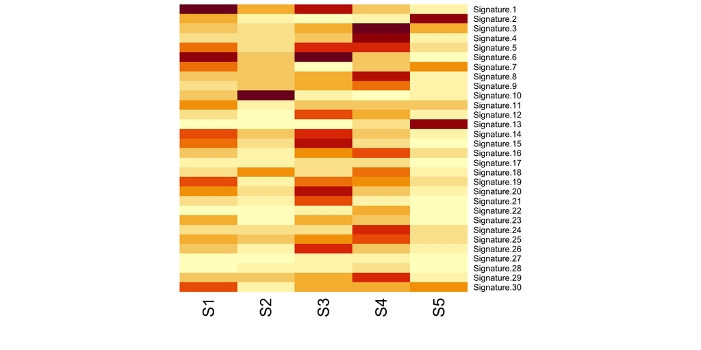

```r
heatmap(t(cs0), Rowv = NA, Colv = NA, scale = 'none', revC = TRUE)
```

In the above, we computed the cosine similarity matrix of the 5 de novo signatures with the COSMIC v2 set. The heatmap indicates that `S1-S5` correspond to Signatures 1 (Aging), 10 (POLE), 6 (MMR), 3 (HRD), and 2 (APOBEC), respectively. The following may be used to obtain an assignment based on such overlaps if visual inspection is ambiguous:

```r
lsap <- clue::solve_LSAP(cs0, maximum = TRUE)
sassign <- colnames(cs0)[lsap]
names(sassign) <- rownames(cs0)
sassign
```

```
#>             S1             S2             S3             S4             S5
#>  "Signature.1" "Signature.10"  "Signature.6"  "Signature.3"  "Signature.2"
```

A function `sigplot` will plot signature profiles to aid comparison:

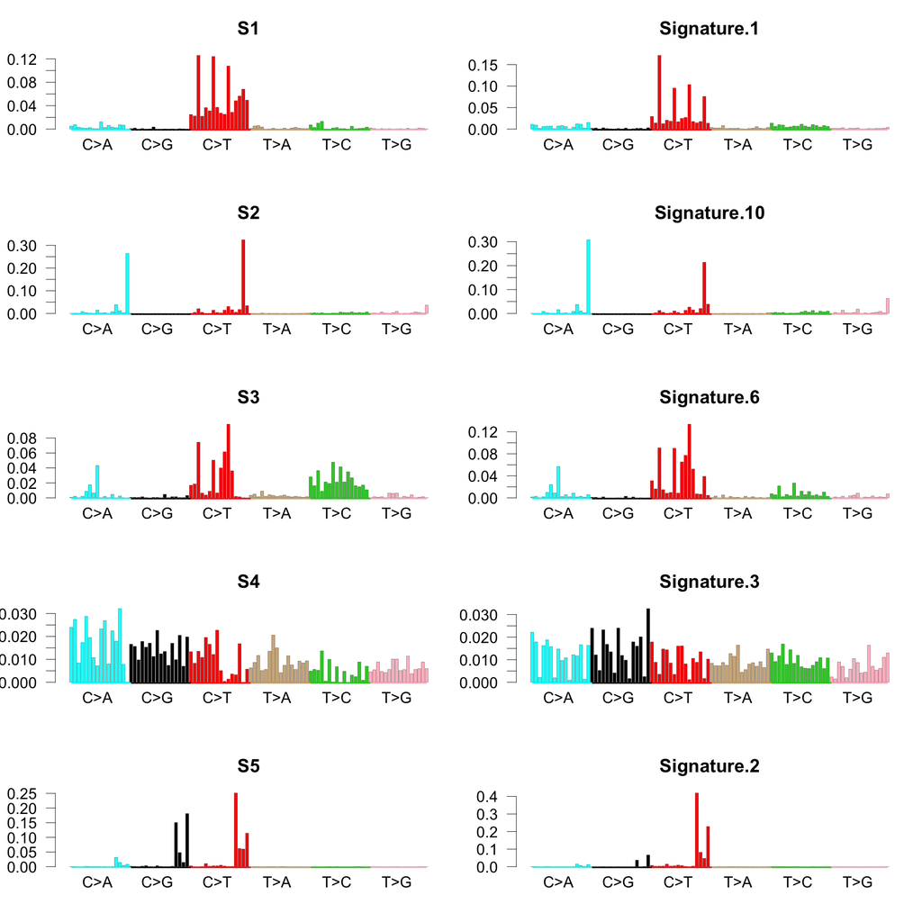

```r
old.par <- par(mfrow = c(5, 2), mar = c(3,3,3,1), lwd = 0.2, cex = 1)
for(k in seq(5)){
  sigplot(sd0[, names(sassign)[k]])
  title(main = names(sassign)[k])
  sigplot(sbs[, sassign[k]])
  title(main = sassign[k])
}
```

```r
par(old.par)
```

## 2.7 De novo inference with variable number of signatures

In the previous de novo inference example, the number of signatures was set as 5, while this number ($K$) is unknown in practice. Commonly, the maximum likelihood NMF is augmented by quality measures (reproducibility of extraction results, etc) to help decide the optimal $K$. A more direct way to determine $K$ is to use a Bayesian formulation and compute marginal likelihood. The non-Bayesian version invoked by `extractSig(..., method = nmf)` above is in fact a special case of this Bayesian algorithm. We scan a range of $K$ values via

```r
set.seed(152)
tscan <- extractSig(tcga, method = 'bnmf', Kmax = 10, nrun = 10, verbose = 1)
```

```
#> Run 1
#> Kmax =  8
#> Run 2
#> Kmax =  9
#> Run 3
#> Run 4
#> Kmax =  7
#> Run 5
#> Kmax =  9
#> Run 6
#> Kmax =  9
#> Run 7
#> Kmax =  7
#> Run 8
#> Kmax =  9
#> Run 9
#> Kmax =  9
#> Run 10
```

```r
me <- misc(tscan)$measure
me
```

```
#>    K       LML
#> 1  2 -1.134082
#> 2  3 -1.062338
#> 3  4 -1.040996
#> 4  5 -1.036085
#> 5  6 -1.034881
#> 6  7 -1.034655
#> 7  8 -1.042157
#> 8  9 -1.043245
#> 9 10 -1.052176
```

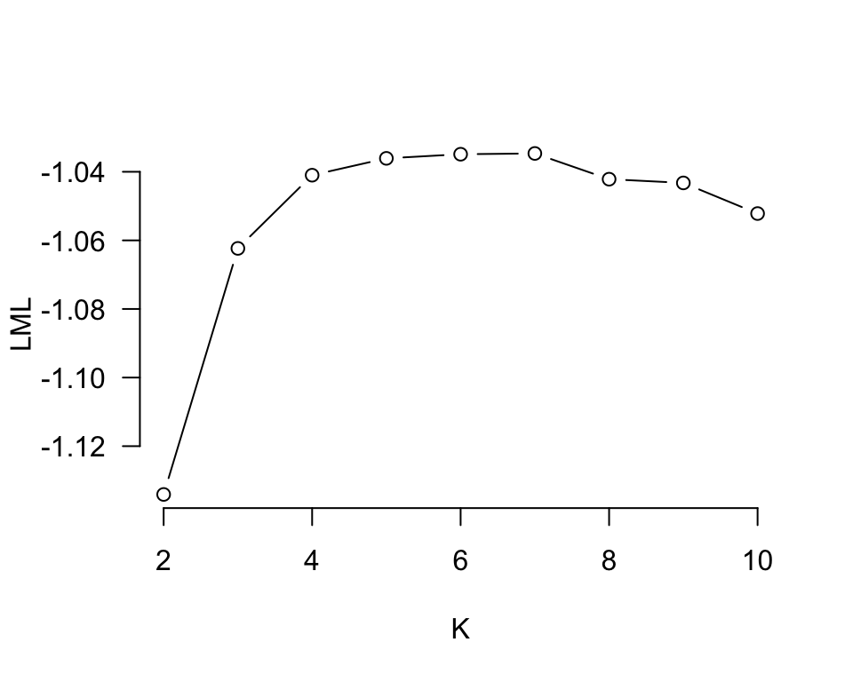

```r
plot(me, type = 'b', las = 1, bty = 'n')
```

Note that individual runs consist of $K$ values scanned from 2 (default) to `Kmax`. Often, increasing the size of signature set by one will result in redundant signatures beyond a certain $K$ value. If this occurrs, the scan will stop and print this upper bound `Kmax`. In the example above, this upper bound is often smaller than the maximum 10. A utility function `kstar` will find the optimal $K$ (cautioned against blind-usages; a visual review is often necessary):

```r
kstar(me)$ropt
```

```
#> [1] 7
```

The object returned by `extractSig(..., method = 'bnmf')` scanning multiple $K$ will in general not contain the desired signature and exposure matrices in its slots. Therefore, one needs to run another inference with a single $K$ determined:

```r
tcga2 <- extractSig(tcga, method = 'bnmf', Kmin = 7, Kmax = 7)
```

```
#> Run 1
#> K = 7: iteration = 203, lkl= -1.044339
#> Run 2
#> Kmax =  6
#> Run 3
#> K = 7: iteration = 182, lkl= -1.038917
#> Run 4
#> K = 7: iteration = 211, lkl= -1.045533
#> Run 5
#> K = 7: iteration = 144, lkl= -1.039885
#> Run 6
#> K = 7: iteration = 242, lkl= -1.04349
#> Run 7
#> K = 7: iteration = 139, lkl= -1.038608
#> Run 8
#> K = 7: iteration = 179, lkl= -1.046159
#> Run 9
#> K = 7: iteration = 138, lkl= -1.035953
#> Run 10
#> K = 7: iteration = 226, lkl= -1.046613
```

```r
tcga2
```

```
#> Class: tempoSig
#> Number of mutation types =  96
#>   [1] "A[C>A]A" "A[C>A]C" "A[C>A]G" "A[C>A]T" "C[C>A]A" "C[C>A]C"
#> Number of samples =  985
#> Number of signatures =  7
#>   [1] "S1" "S2" "S3" "S4" "S5" "S6"
```

It is worth noting that this single-$K$ run output uses a model more general (gamma priors with hyper-parameter optmized) than the non-Bayesian version obtained with `method = 'nmf'`.

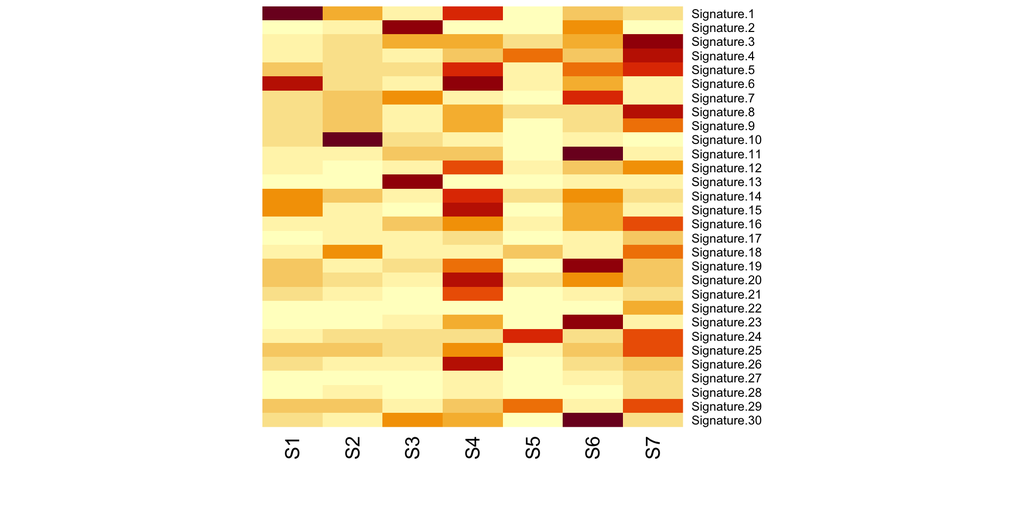

```r
sd1 <- signat(tcga2)
cs2 <- cosineSimilarity(A = sd1, B = sbs)
heatmap(t(cs2), Rowv = NA, Colv = NA, scale = 'none', revC = TRUE)
```

```r
lsap2 <- clue::solve_LSAP(cs2, maximum = TRUE)
sassign2 <- colnames(cs2)[lsap2]
names(sassign2) <- rownames(cs2)
sassign2
```

```
#>             S1             S2             S3             S4             S5
#>  "Signature.1" "Signature.10"  "Signature.2"  "Signature.6" "Signature.24"
#>             S6             S7
#> "Signature.11"  "Signature.3"
```

Two additional signatures found here resemble Signature 24 and Signature 11.

# References

Alexandrov, L. B., J. Kim, N. J. Haradhvala, M. N. Huang, A. W. Tian Ng, Y. Wu, A. Boot, et al. 2020. “The repertoire of mutational signatures in human cancer.” *Nature* 578 (7793): 94–101.

Alexandrov, L. B., S. Nik-Zainal, D. C. Wedge, P. J. Campbell, and M. R. Stratton. 2013. “Deciphering signatures of mutational processes operative in human cancer.” *Cell Rep* 3 (1): 246–59.

Bishop, C. 2006. *Pattern Recognition and Machine Learning*. New York: Springer.

Cemgil, A. T. 2009. “Bayesian Inference for Nonnegative Matrix Factorisation Models” 2009: 785152.

DeGroot, M. H., and M. J. Schervish. 2012. *Probability and Statistics*. Boston, MA: Pearson.

Lee, D. D., and Seung S. 1999. “Learning the Parts of Objects by Non-Negative Matrix Factorization.” *Nature*, 788–91.

Nik-Zainal, S., L. B. Alexandrov, D. C. Wedge, P. Van Loo, C. D. Greenman, K. Raine, D. Jones, et al. 2012. “Mutational processes molding the genomes of 21 breast cancers.” *Cell* 149 (5): 979–93.

Rosenthal, R., N. McGranahan, J. Herrero, B. S. Taylor, and C. Swanton. 2016. “DeconstructSigs: delineating mutational processes in single tumors distinguishes DNA repair deficiencies and patterns of carcinoma evolution.” *Genome Biol.* 17 (February): 31.